# US Border Entry

Varun Vasudeva

This report aims to build a simple predictive model for the number of entrants in a month given a year between 1996 and 2020, a port of entry, and a mode of transportation. In it, we will explore the data and draw inferences about trends, build successive linear regression models using multiple predictors, and eventually validate the model to determine the true error of prediction.

After loading the necessary libraries for analysis, we can read the data from the comma-separated-value (CSV) file and view the first 6 entries. The data was sourced from https://www.kaggle.com/divyansh22/us-border-crossing-data and is a dataset involving the US Border and crossing data related to it.

```r
border <- read.csv("Border_Crossing_Entry_Data.csv")
head(border)
```

```
##        Port.Name State Port.Code           Border           Date
## 1          Alcan    AK      3104 US-Canada Border 2/1/2020 00:00
## 2          Alcan    AK      3104 US-Canada Border 2/1/2020 00:00
## 3          Alcan    AK      3104 US-Canada Border 2/1/2020 00:00
## 4          Alcan    AK      3104 US-Canada Border 2/1/2020 00:00
## 5          Alcan    AK      3104 US-Canada Border 2/1/2020 00:00
## 6 Alexandria Bay    NY       708 US-Canada Border 2/1/2020 00:00
##                       Measure Value
## 1 Personal Vehicle Passengers  1414
## 2           Personal Vehicles   763
## 3      Truck Containers Empty   412
## 4       Truck Containers Full   122
## 5                      Trucks   545
## 6              Bus Passengers  1174
```

Next, we need to reconstruct the data in order to assist with meaningful exploratory data analysis (or EDA) so we can glean relevant information from the graphs. We’ve extracted the year from the Date column and allotted it to a separate column called `Year`.

We’ve also split the data into five sections: 1996 - 2000, 2001 - 2005, 2006 - 2010, 2011 - 2015, and 2016 - 2020. This will help us analyze what happens to immigration into the United States over these five periods, so we can gather a general trend.

```r
border <- border %>%
  mutate(Year = format(as.Date(border$Date, format="%d/%m/%Y"),"%Y"),
         ModYear = case_when(Year >= 1996 & Year <= 2000 ~ "1996 - 2000",
                            Year >= 2001 & Year <= 2005 ~ "2001 - 2005",
                            Year >= 2006 & Year <= 2010 ~ "2006 - 2010",
                            Year >= 2011 & Year <= 2015 ~ "2011 - 2015",
                            Year >= 2016 & Year <= 2020 ~ "2016 - 2020")) %>%
  filter(!Value %in% c(0)) %>%
  drop_na()
head(border)
```

```
##        Port.Name State Port.Code           Border           Date
## 1          Alcan    AK      3104 US-Canada Border 2/1/2020 00:00
## 2          Alcan    AK      3104 US-Canada Border 2/1/2020 00:00
## 3          Alcan    AK      3104 US-Canada Border 2/1/2020 00:00
## 4          Alcan    AK      3104 US-Canada Border 2/1/2020 00:00
## 5          Alcan    AK      3104 US-Canada Border 2/1/2020 00:00
## 6 Alexandria Bay    NY       708 US-Canada Border 2/1/2020 00:00
##                       Measure Value Year     ModYear
## 1 Personal Vehicle Passengers  1414 2020 2016 - 2020
## 2           Personal Vehicles   763 2020 2016 - 2020
## 3      Truck Containers Empty   412 2020 2016 - 2020
## 4       Truck Containers Full   122 2020 2016 - 2020
## 5                      Trucks   545 2020 2016 - 2020
## 6              Bus Passengers  1174 2020 2016 - 2020
```

We’ve reconstructed the data in order to exclude Value entries that are equal to 0, for purposes that will be discussed later on.

We can utilize a bar graph facet-wrapped by `ModYear` to observe a trend in immigration patterns over the five splits from 1996 - 2020.

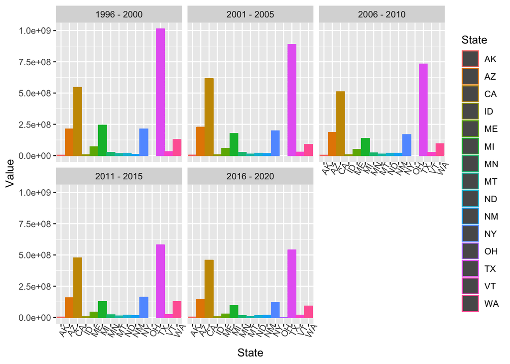

```r
ggplot(border, aes(x = State, y = Value, col = State)) +
  geom_bar(stat = "identity") +
  facet_wrap(~ModYear) +
  theme(axis.text.x = element_text(angle = 60))
```

We see clearly that Texas has the greatest immigration influx out of all states that contribute to the influx of immigrants. California stands second in terms of number of immigrants coming into the United States, and Arizona stands third.

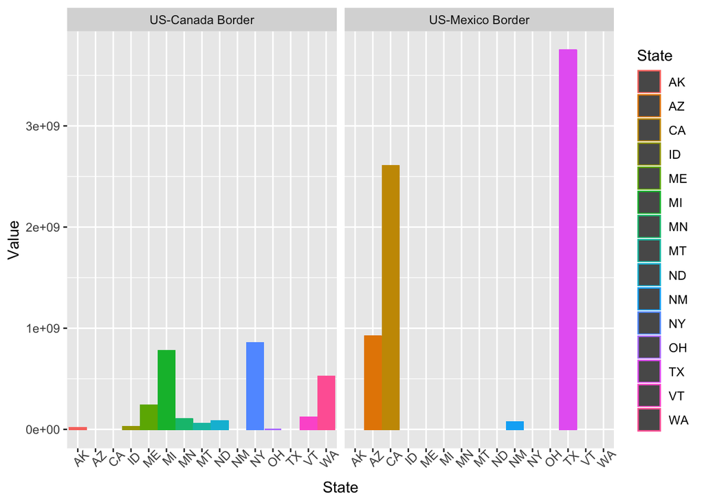

```r
ggplot(border, aes(x = State, y = Value, col = State)) +
  geom_bar(stat = "identity") +
  facet_wrap(~Border) +
  theme(axis.text.x = element_text(angle = 45))
```

New Mexico is the lowest contributor to the US-Mexico border and Ohio seems to be the lowest contributor to the US-Canada border.

Next, we’ll create a full linear regression model both so we can see how it performs and for the purpose of eliminating unnecessary variables using the `step()` function, which will perform a stepwise elimination of irrelevant variables. These following models are aimed at predicting the number of incoming migrants from a particular port of entry in an arbitrary month in a given year.

```r
border.full <- lm(Value ~ Port.Name + State + Port.Code + Border + Measure + Year, data = border)
summary(border.full)
```

[output not shown]

[output cut: 129 more lines]

[output not shown]

```r
border.reduced <- lm(Value ~ Port.Name + Port.Code + Border + Measure + Year, data = border)
summary(border.reduced)
```

```
##
## Call:
## lm(formula = Value ~ Port.Name + Port.Code + Border + Measure +
##     Year, data = border)
##
## Residuals:
##     Min      1Q  Median      3Q     Max
## -788805  -43486    6897   39208 3915188
##
## Coefficients: (1 not defined because of singularities)
##                                       Estimate Std. Error t value Pr(>|t|)
## (Intercept)                         -70087.712   5751.634 -12.186  < 2e-16 ***
## Port.NameAlexandria Bay              46934.655   5669.607   8.278  < 2e-16 ***
## Port.NameAlgonac                    -49391.411  25606.220  -1.929 0.053747 .
## Port.NameAmbrose                    -44884.733   5565.096  -8.065 7.33e-16 ***
## Port.NameAnacortes                  -21673.588   6546.494  -3.311 0.000931 ***
## Port.NameAndrade                     29639.923   4993.008   5.936 2.92e-09 ***
## Port.NameAntler                     -27407.374   5111.853  -5.362 8.26e-08 ***
## Port.NameBar Harbor                   9401.219  13035.502   0.721 0.470786
## Port.NameBaudette                    15810.995   4261.974   3.710 0.000207 ***
## Port.NameBeecher Falls               13520.312   6265.691   2.158 0.030942 *
## Port.NameBlaine                     117715.622   4116.766  28.594  < 2e-16 ***
## Port.NameBoquillas                   17375.038  21328.416   0.815 0.415278
## Port.NameBoundary                    16872.312   4543.178   3.714 0.000204 ***
## Port.NameBridgewater                  9672.757   6421.733   1.506 0.132003
## Port.NameBrownsville                195169.894   4289.502  45.499  < 2e-16 ***
## Port.NameBuffalo-Niagara Falls      206964.929   5153.517  40.160  < 2e-16 ***
## Port.NameCalais                      68362.039   5909.984  11.567  < 2e-16 ***
## Port.NameCalexico                   392474.288   5239.888  74.901  < 2e-16 ***
## Port.NameCalexico East              102807.291   4201.905  24.467  < 2e-16 ***
## Port.NameCape Vincent               -74603.808  12644.084  -5.900 3.63e-09 ***
## Port.NameCarbury                    -20742.406   5014.691  -4.136 3.53e-05 ***
## Port.NameChamplain-Rouses Point      76376.318   5317.930  14.362  < 2e-16 ***
## Port.NameColumbus                    19689.942   4566.967   4.311 1.62e-05 ***
## Port.NameCross Border Xpress        134980.384  27285.982   4.947 7.55e-07 ***
## Port.NameDalton Cache                -3001.412   4530.585  -0.662 0.507666
## Port.NameDanville                      303.723   4581.951   0.066 0.947150
## Port.NameDel Bonita                 -24468.468   5019.201  -4.875 1.09e-06 ***
## Port.NameDel Rio                     65366.379   4677.598  13.974  < 2e-16 ***
## Port.NameDerby Line                  43795.874   6015.564   7.280 3.34e-13 ***
```

[output cut: 115 more lines]

```
## Year2012                            -12800.996   2172.887  -5.891 3.84e-09 ***
## Year2013                            -11770.335   2179.470  -5.401 6.65e-08 ***
## Year2014                            -11689.017   2180.224  -5.361 8.27e-08 ***
## Year2015                            -11200.396   2178.196  -5.142 2.72e-07 ***
## Year2016                            -11369.959   2178.857  -5.218 1.81e-07 ***
## Year2017                            -10541.000   2174.804  -4.847 1.26e-06 ***
## Year2018                            -10513.150   2179.352  -4.824 1.41e-06 ***
## Year2019                            -11332.196   2176.197  -5.207 1.92e-07 ***
## Year2020                            -15181.771   4033.482  -3.764 0.000167 ***
## ---
## Signif. codes:  0 '***' 0.001 '**' 0.01 '*' 0.05 '.' 0.1 ' ' 1
##
## Residual standard error: 145700 on 232967 degrees of freedom
## Multiple R-squared:  0.3859, Adjusted R-squared:  0.3855
## F-statistic: 969.4 on 151 and 232967 DF,  p-value: < 2.2e-16
```

However, we want to see whether the model can be improved (or even kept largely the same) without the presence of as many variables. Now, we create the backward stepwise model.

```r
border.backward <- step(border.reduced, direction = "backward")
```

```
## Start:  AIC=5543302
## Value ~ Port.Name + Port.Code + Border + Measure + Year
##
##
## Step:  AIC=5543302
## Value ~ Port.Name + Port.Code + Measure + Year
##
##              Df  Sum of Sq        RSS     AIC
## <none>                     4.9435e+15 5543302
## - Port.Code   1 5.0706e+11 4.9440e+15 5543324
## - Year       24 1.1691e+13 4.9552e+15 5543804
## - Measure    11 1.0305e+15 5.9740e+15 5587419
## - Port.Name 115 2.2001e+15 7.1436e+15 5628894
```

This process removed the variable `Border`. It is understandable that `Border` does not need to be present in the model as `Border` simply reaffirms what `Port.Name` already tells us. It also makes sense that we need the year along with what measure of travel we’re trying to predict the influx of immigrants for.

```r
summary(border.backward)
```

```
##
## Call:
## lm(formula = Value ~ Port.Name + Port.Code + Measure + Year,
##     data = border)
##
## Residuals:
##     Min      1Q  Median      3Q     Max
## -788805  -43486    6897   39208 3915188
##
## Coefficients:
##                                       Estimate Std. Error t value Pr(>|t|)
## (Intercept)                         -70087.712   5751.634 -12.186  < 2e-16 ***
## Port.NameAlexandria Bay              46934.655   5669.607   8.278  < 2e-16 ***
## Port.NameAlgonac                    -49391.411  25606.220  -1.929 0.053747 .
## Port.NameAmbrose                    -44884.733   5565.096  -8.065 7.33e-16 ***
## Port.NameAnacortes                  -21673.588   6546.494  -3.311 0.000931 ***
## Port.NameAndrade                     29639.923   4993.008   5.936 2.92e-09 ***
## Port.NameAntler                     -27407.374   5111.853  -5.362 8.26e-08 ***
## Port.NameBar Harbor                   9401.219  13035.502   0.721 0.470786
## Port.NameBaudette                    15810.995   4261.974   3.710 0.000207 ***
## Port.NameBeecher Falls               13520.312   6265.691   2.158 0.030942 *
## Port.NameBlaine                     117715.622   4116.766  28.594  < 2e-16 ***
## Port.NameBoquillas                   17375.038  21328.416   0.815 0.415278
## Port.NameBoundary                    16872.312   4543.178   3.714 0.000204 ***
## Port.NameBridgewater                  9672.757   6421.733   1.506 0.132003
## Port.NameBrownsville                195169.894   4289.502  45.499  < 2e-16 ***
## Port.NameBuffalo-Niagara Falls      206964.929   5153.517  40.160  < 2e-16 ***
## Port.NameCalais                      68362.039   5909.984  11.567  < 2e-16 ***
## Port.NameCalexico                   392474.288   5239.888  74.901  < 2e-16 ***
## Port.NameCalexico East              102807.291   4201.905  24.467  < 2e-16 ***
## Port.NameCape Vincent               -74603.808  12644.084  -5.900 3.63e-09 ***
## Port.NameCarbury                    -20742.406   5014.691  -4.136 3.53e-05 ***
## Port.NameChamplain-Rouses Point      76376.318   5317.930  14.362  < 2e-16 ***
## Port.NameColumbus                    19689.942   4566.967   4.311 1.62e-05 ***
## Port.NameCross Border Xpress        134980.384  27285.982   4.947 7.55e-07 ***
## Port.NameDalton Cache                -3001.412   4530.585  -0.662 0.507666
## Port.NameDanville                      303.723   4581.951   0.066 0.947150
## Port.NameDel Bonita                 -24468.468   5019.201  -4.875 1.09e-06 ***
## Port.NameDel Rio                     65366.379   4677.598  13.974  < 2e-16 ***
## Port.NameDerby Line                  43795.874   6015.564   7.280 3.34e-13 ***
```

[output cut: 114 more lines]

```
## Year2012                            -12800.996   2172.887  -5.891 3.84e-09 ***
## Year2013                            -11770.335   2179.470  -5.401 6.65e-08 ***
## Year2014                            -11689.017   2180.224  -5.361 8.27e-08 ***
## Year2015                            -11200.396   2178.196  -5.142 2.72e-07 ***
## Year2016                            -11369.959   2178.857  -5.218 1.81e-07 ***
## Year2017                            -10541.000   2174.804  -4.847 1.26e-06 ***
## Year2018                            -10513.150   2179.352  -4.824 1.41e-06 ***
## Year2019                            -11332.196   2176.197  -5.207 1.92e-07 ***
## Year2020                            -15181.771   4033.482  -3.764 0.000167 ***
## ---
## Signif. codes:  0 '***' 0.001 '**' 0.01 '*' 0.05 '.' 0.1 ' ' 1
##
## Residual standard error: 145700 on 232967 degrees of freedom
## Multiple R-squared:  0.3859, Adjusted R-squared:  0.3855
## F-statistic: 969.4 on 151 and 232967 DF,  p-value: < 2.2e-16
```

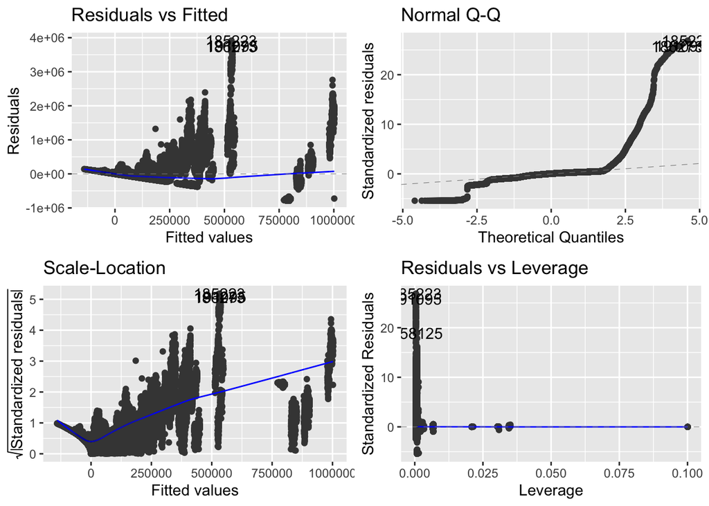

```r
autoplot(border.backward)
```

This backwards stepwise model has an F-statistic = 969.4 on 151 and 232967 df with RSE = 145700 on 232967 df. The p-value, Adjusted R-squared, and RSE are the same as the reduced model, but the model is simpler and requires less data for predictive purposes, so this is the one we keep and carry on with.

However, we see major issues with normality and the Residuals vs. Leverage plot having an extremely high y-axis range. We can run a Box-Cox test in order to determine how to fix these issues. This is why we reconstructed the data to remove all Value entries that were 0. In case a log transformation is necessary, data points with a Value = 0 would throw off the test and make it impossible to diagnose the rest of the data points.

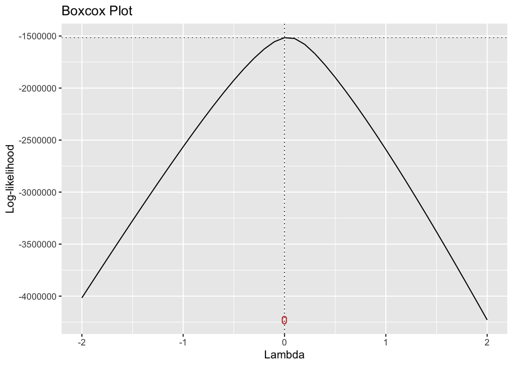

```r
gg_boxcox(border.backward)
```

As we can see from the output above, the ideal $\lambda$ value = 0, meaning a log transformation would suffice in attempting to fix issues as shown by the `autoplot()` function. We now create a new model called `border.fit` in order to improve on the backward stepwise model. In this mode, however, we will omit `Port.Code` simply because having the value for `Port.Name` gives us the value for `Port.Code` already.

```r
border.fit <- lm(log(Value) ~ Port.Name + Measure + Year, data = border)
summary(border.fit)
```

```
##
## Call:
## lm(formula = log(Value) ~ Port.Name + Measure + Year, data = border)
##
## Residuals:
##      Min       1Q   Median       3Q      Max
## -10.6057  -0.7052   0.0979   0.8087   6.8272
##
## Coefficients:
##                                      Estimate Std. Error  t value Pr(>|t|)
## (Intercept)                          4.519881   0.035173  128.503  < 2e-16 ***
## Port.NameAlexandria Bay              3.248531   0.043300   75.023  < 2e-16 ***
## Port.NameAlgonac                    -0.093089   0.243538   -0.382 0.702288
## Port.NameAmbrose                    -3.090557   0.052812  -58.520  < 2e-16 ***
## Port.NameAnacortes                  -0.235401   0.062301   -3.778 0.000158 ***
## Port.NameAndrade                     1.999241   0.046825   42.696  < 2e-16 ***
## Port.NameAntler                     -1.431819   0.048479  -29.535  < 2e-16 ***
## Port.NameBar Harbor                 -0.246048   0.117415   -2.096 0.036124 *
## Port.NameBaudette                    1.181328   0.040350   29.277  < 2e-16 ***
## Port.NameBeecher Falls               0.377945   0.045170    8.367  < 2e-16 ***
## Port.NameBlaine                      4.621501   0.039153  118.038  < 2e-16 ***
## Port.NameBoquillas                   2.587943   0.202802   12.761  < 2e-16 ***
## Port.NameBoundary                   -0.209206   0.043222   -4.840 1.30e-06 ***
## Port.NameBridgewater                 0.482722   0.046206   10.447  < 2e-16 ***
## Port.NameBrownsville                 4.478710   0.039327  113.885  < 2e-16 ***
## Port.NameBuffalo-Niagara Falls       5.240221   0.038952  134.530  < 2e-16 ***
## Port.NameCalais                      2.031530   0.039186   51.844  < 2e-16 ***
## Port.NameCalexico                    4.887009   0.049204   99.321  < 2e-16 ***
## Port.NameCalexico East               3.061801   0.039139   78.228  < 2e-16 ***
## Port.NameCape Vincent               -1.058943   0.115982   -9.130  < 2e-16 ***
## Port.NameCarbury                    -1.301708   0.047540  -27.382  < 2e-16 ***
## Port.NameChamplain-Rouses Point      3.858919   0.038924   99.139  < 2e-16 ***
## Port.NameColumbus                    1.948804   0.042447   45.911  < 2e-16 ***
## Port.NameCross Border Xpress         7.169426   0.259625   27.615  < 2e-16 ***
## Port.NameDalton Cache               -0.847475   0.043124  -19.652  < 2e-16 ***
## Port.NameDanville                   -0.525917   0.043590  -12.065  < 2e-16 ***
## Port.NameDel Bonita                 -1.266752   0.047687  -26.564  < 2e-16 ***
## Port.NameDel Rio                     3.195879   0.043196   73.986  < 2e-16 ***
## Port.NameDerby Line                  2.791201   0.042002   66.453  < 2e-16 ***
## Port.NameDetroit                     5.199364   0.039512  131.588  < 2e-16 ***
```

[output cut: 112 more lines]

```
## Year2012                             0.012040   0.020680    0.582 0.560421
## Year2013                             0.003242   0.020742    0.156 0.875788
## Year2014                             0.001455   0.020749    0.070 0.944112
## Year2015                            -0.047884   0.020730   -2.310 0.020897 *
## Year2016                            -0.072209   0.020737   -3.482 0.000497 ***
## Year2017                            -0.068093   0.020698   -3.290 0.001003 **
## Year2018                            -0.093033   0.020742   -4.485 7.28e-06 ***
## Year2019                            -0.134187   0.020711   -6.479 9.25e-11 ***
## Year2020                            -0.266332   0.038391   -6.937 4.01e-12 ***
## ---
## Signif. codes:  0 '***' 0.001 '**' 0.01 '*' 0.05 '.' 0.1 ' ' 1
##
## Residual standard error: 1.387 on 232968 degrees of freedom
## Multiple R-squared:  0.7981, Adjusted R-squared:  0.7979
## F-statistic:  6139 on 150 and 232968 DF,  p-value: < 2.2e-16
```

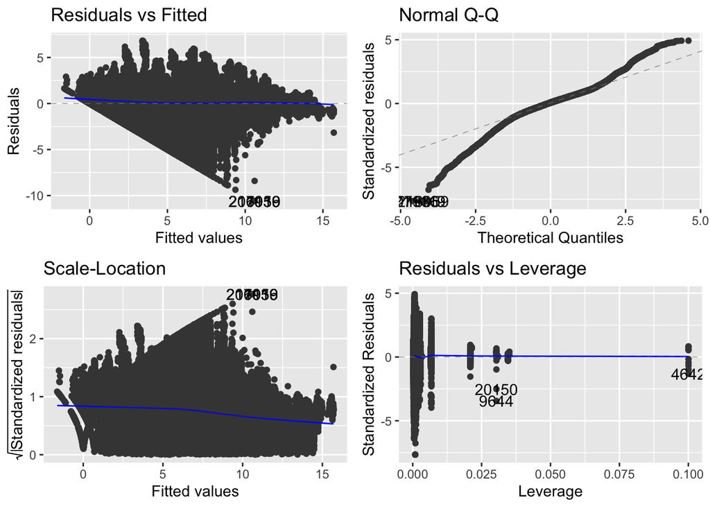

```r
autoplot(border.fit)
```

Next, we run a 5-fold cross validation in order to create a slightly more realistic model that doesn’t predict the same data it’s trained with.

```r
set.seed(536255)
train_control <- trainControl(method = "cv", number = 5)
border.cv <- train(log(Value) ~ Port.Name + Measure + Year, data = border, trControl = train_control, method="lm")
print(border.cv)
```

```
## Linear Regression
##
## 233119 samples
##      3 predictor
##
## No pre-processing
## Resampling: Cross-Validated (5 fold)
## Summary of sample sizes: 186495, 186496, 186495, 186495, 186495
## Resampling results:
##
##   RMSE      Rsquared   MAE
##   1.387064  0.7977991  1.017155
##
## Tuning parameter 'intercept' was held constant at a value of TRUE
```

The RMSE is 1.387064, which is the same as the RSE of 1.387 on the previous model. This model is the most accurate one so far, by virtue of it iteratively predicting different data that what the model was trained on. Thus, we can go ahead and make a prediction using the `border.cv` model.

```r
new_data = data.frame(Port.Name = "Santa Teresa", Measure = "Buses", Year = "2010")
exp(predict(border.cv, newdata = new_data))
```

```
##        1
## 37.10143
```

```r
test.df <- data.frame(filter(border, Port.Name == "Santa Teresa" & Measure == "Buses" & Year == "2010"))
mean(test.df$Value)
```

```
## [1] 36.66667
```

This sample prediction states that in a month in 2010, from the port of Santa Teresa, NM, 37 people will enter the United States via the Buses Measure. Comparing it to the average of the months in 2010 with the same criterion applied, we see that the model over-predicts by a very small margin. However, it gives an accurate estimate of how many people can be expected in a given month. Also, considering the RMSE of the model is 1.387 with 233119 samples, the model is fairly accurate.

Over the last two seasons (2011 - 2015 and 2016 - 2020), the data has remained fairly consistent, as seen in our EDA. Thus, this model can be used to predict future data from past data.